# Kansas City Mental Health Survey

### Sleep quality

Sleep and mental health have a two-way relationship: lack of sleep can negatively impact mental health, and mental health issues can, in turn, make it harder to sleep. This creates a cycle that can be difficult to break.

Sleep deprivation has a profound and immediate effect on one's mental state. Even a few nights of poor sleep can lead to increased feelings of anxiety, irritability, and stress. Over time, this can significantly raise the risk of developing more serious mental health conditions, like depression and/or anxiety. Sleep is essential for the brain to process emotions and regulate mood. Without enough sleep, the brain struggles to manage its emotional responses, which can lead to more intense and unpredictable moods, difficulty coping with daily stressors, and an overall reduction in positive emotions.

The following questions highlight several components of sleep that contribute to a person's overall sleep quality.

**Habitual sleep efficiency score**

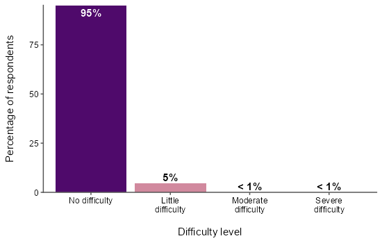

Figure 28: N = 612.

Habitual sleep efficiency is a measure of sleep quality that accounts for the time a person spends trying to fall asleep. Perfect sleep efficiency occurs when a person spends 100% of their time in bed sleeping, with no time spent waiting to fall asleep. This means that perfect sleep efficiency can result from any amount of sleep if a person falls asleep as soon as they are in bed. Most respondents (95%) said they had no difficulty sleeping.

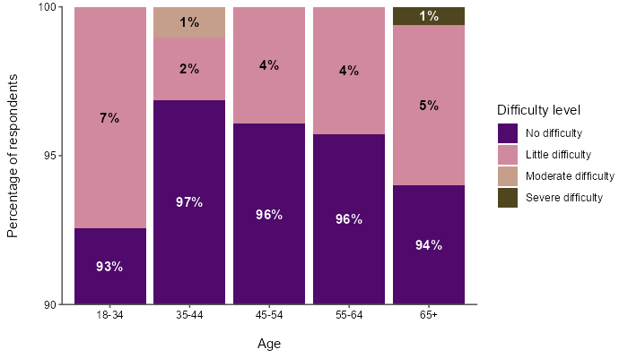

Figure 29: N = 576. Note the truncated y-axis scale.

When results are grouped by age, the only respondents with moderate difficulty sleeping were in the 35-44 age group. The only respondents with severe difficulty sleeping were in the 65+ age group.

**During the past month, how many hours of sleep did you get at night?**

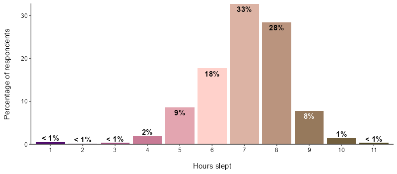

Figure 30: N = 626.

Table 2: Age-adjusted sleep duration in adults

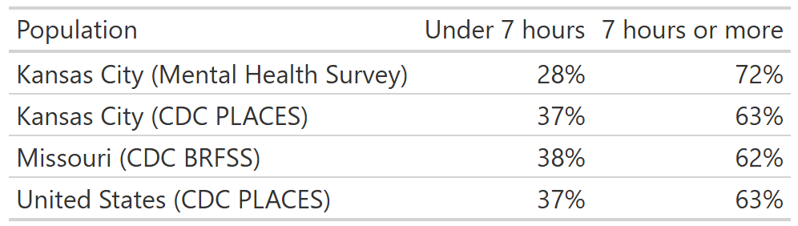

**During the past month, how long has it usually taken you to fall asleep each night?**

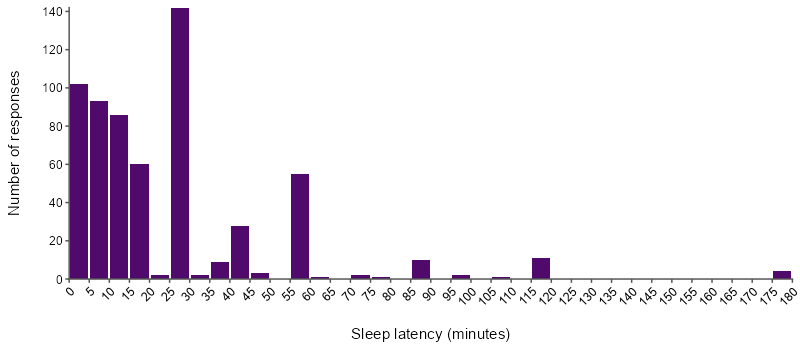

Figure 31: N = 614.

Sleep latency is the amount of time it takes a person to fall asleep. A normal sleep latency of 10-20 minutes is commonly cited. Regularly experiencing a much longer or shorter sleep latency may be an indicator of disordered sleeping.[^13]

Table 3: Sleep latency descriptive statistics

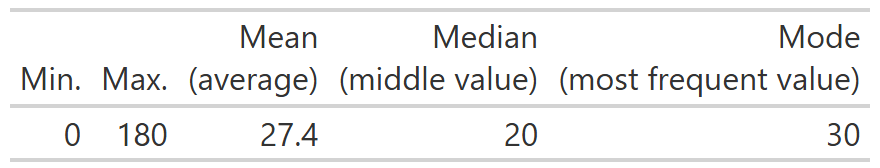

Survey respondents reported sleep latencies ranging from 0 to 180 minutes (3 hours). The average (mean) sleep latency was 27.4 minutes. The most frequently reported sleep latency was 30 minutes.

## Conclusion

The 2024 Kansas City mental health survey provides one of the first pictures to date of emotional distress, disconnection, and unmet mental health need in our city. Symptoms of anxiety and depression are broadly consistent with national trends, reported by about 1 in 5 adults, but our local data reveal some specific structural barriers that limit residents’ ability to access care to address these needs. Twenty-five percent (25%) of residents who needed care couldn’t get it, most often due to cost, lack of information, or insurance limitations. At the same time, another 1 in 4 is actively receiving care, suggesting that when services are available and accessible, people will use them. Loneliness is also prevalent, particularly among younger adults. Nearly half of residents under age 54 are at moderate or high risk of disconnection, an indicator that emotional strain is not just about clinical symptoms, but about how people are connecting to their communities. Taken together, these results serve as a guide to demonstrate Kansas City’s clear mental health needs and can inform the citywide initiatives needed to address them. These findings reveal not just personal struggles, but system-level gaps in how mental health is supported and delivered. The conclusions within this report aim to help spark a response and to guide next steps in improving access, trust, and support for mental wellbeing across our city.

## Footnotes

[^1]: Terlizzi, E. P., & Zablotsky, B. (2024). Symptoms of anxiety and depression among adults: United States, 2019 and 2022 (National Health Statistics Reports No. 213). National Center for Health Statistics.
[^2]: The ZCTA analysis was conducted using a 1:1 ZIP code to ZCTA match.
[^3]: U.S. Census Bureau. (2025). 2024 American Community Survey 1-Year Estimates [Data set]. https://www.census.gov/programs-surveys/acs/data/summary-file.2024.html
[^4]: Responses indicating low frequency included "None of the time", "A little of the time", "Not at all", "At least 1 week", and "Hardly ever". Responses indicating moderate to high frequency included all other responses.
[^5]: Substance Abuse and Mental Health Services Administration (SAMHSA). (April 24, 2023). Certified Community Behavioral Health Clinics (CCBHCs). U.S. Department of Health and Human Services. https://www.samhsa.gov/communities/certified-community-behavioral-health-clinics
[^6]: Cacioppo, J. T., & Hawkley, L. C. (2009). Perceived social isolation and cognition. *Trends in cognitive sciences*, *13*(10), 447-454. https://doi.org/10.1016/j.tics.2009.06.005
[^7]: National Academies of Sciences, Engineering, and Medicine. (2020). Social isolation and loneliness in older adults: Opportunities for the health care system. https://doi.org/10.17226/25663
[^8]: Riehm, K. E., Feder, K. A., Tormohlen, K. N., Crum, R. M., Young, A. S., Green, K. M., ... & Mojtabai, R. (2019). Associations between time spent using social media and internalizing and externalizing problems among US youth. *JAMA psychiatry*, *76*(12), 1266-1273.
[^9]: Centers for Disease Control and Prevention (CDC). (October 29, 2024). Health Risk Behaviors. U.S. Department of Health and Human Services. https://www.cdc.gov/places/measure-definitions/health-risk-behaviors.html#cdc_data_surveillance_section_4-short-sleep-duration-among-adults
[^10]: Itani, O., Jike, M., Watanabe, N., & Kaneita, Y. (2017). Short sleep duration and health outcomes: a systematic review, meta-analysis, and meta-regression. *Sleep medicine*, *32*, 246-256. https://doi.org/10.1016/j.sleep.2016.08.006
[^11]: Centers for Disease Control and Prevention. (2024). PLACES: Local Data for Better Health, Place Data 2024 release [Data set]. https://data.cdc.gov/500-Cities-Places/PLACES-Local-Data-for-Better-Health-Place-Data-202/eav7-hnsx/about_data
[^12]: Centers for Disease Control and Prevention (CDC). (May 15, 2024). FastStats: Sleep in Adults. U.S. Department of Health and Human Services. https://www.cdc.gov/sleep/data-research/facts-stats/adults-sleep-facts-and-stats.html
[^13]: Holder, S., & Narula, N. S. (2022). Common sleep disorders in adults: diagnosis and management. *American family physician*, *105*(4), 397-405. PMID: 35426627.